# Web Mining and Applied NLP (44-620)

## Final Project: Article Summarizer

### Student Name: Tanya Fagaly

### Link to repository: https://github.com/RealNumberI/44620Mod7Repository.git

Perform the tasks described in the Markdown cells below. When you have completed the assignment make sure your code cells have all been run (and have output beneath them) and ensure you have committed and pushed ALL of your changes to your assignment repository.

You should bring in code from previous assignments to help you answer the questions below.

Every question that requires you to write code will have a code cell underneath it; you may either write your entire solution in that cell or write it in a python file (`.py`), then import and run the appropriate code to answer the question.

1. Find on the internet an article or blog post about a topic that interests you and you are able to get the text for using the technologies we have applied in the course. Get the html for the article and store it in a file (which you must submit with your project)

## Question 1

```python
import requests
from bs4 import BeautifulSoup
import pickle
import spacy
from spacytextblob.spacytextblob import SpacyTextBlob

article_page = requests.get('https://web.archive.org/web/20210322201507/https://hackaday.com/2021/03/20/')
#article_html = article_page.text

with open('python-match.pkl', 'wb') as f:
    pickle.dump(article_page.text, f)

with open('python-match.pkl', 'rb') as f:
    article_html = pickle.load(f)
    soup = BeautifulSoup(article_html, 'html5lib')

article_content = soup.find('article')
```

1. Read in your article's html source from the file you created in question 1 and do sentiment analysis on the article/post's text (use `.get_text()`). Print the polarity score with an appropriate label. Additionally print the number of sentences in the original article (with an appropriate label) ## Question 2

```python
nlp = spacy.load('en_core_web_sm')
nlp.add_pipe("spacytextblob")
doc = nlp(article_content.get_text())
doc._.blob.polarity

print("Article's polarity score: ", doc._.blob.polarity)

sentences = list(doc.sents)
print("Number of sentences in the the article: ", len(sentences))
```

```
Article's polarity score:  0.15049407114624505
Number of sentences in the the article:  19
```

1. Load the article text into a trained `spaCy` pipeline, and determine the 5 most frequent tokens (converted to lower case). Print the common tokens with an appropriate label. Additionally, print the tokens their frequencies (with appropriate labels) ## Question 3

```python
def we_care_about(token):
    return not (token.is_space or token.is_punct or token.is_stop)

interesting_tokens = [token for token in doc if we_care_about(token)]
interesting_tokens_lower = [token.text.lower() for token in doc if we_care_about(token)]

from collections import Counter
word_freq = Counter(map(str,interesting_tokens_lower))

print("Five most frequent tokens and frequency: ", word_freq.most_common(5))
```

```
Five most frequent tokens and frequency:  [('3070', 6), ('gb', 6), ('ram', 5), ('rtx', 5), ('memory', 5)]
```

1. Load the article text into a trained `spaCy` pipeline, and determine the 5 most frequent lemmas (converted to lower case). Print the common lemmas with an appropriate label. Additionally, print the lemmas with their frequencies (with appropriate labels). ## Question 4

```python
interesting_lemmas = [token.lemma_.lower() for token in doc if we_care_about(token)]
lemma_freq = Counter(interesting_lemmas)
print("Five most frequent lemmas and frequency: ",lemma_freq.most_common(5))
```

```
Five most frequent lemmas and frequency:  [('3070', 6), ('gb', 6), ('ram', 5), ('rtx', 5), ('memory', 5)]
```

1. Make a list containing the scores (using tokens) of every sentence in the article, and plot a histogram with appropriate titles and axis labels of the scores. From your histogram, what seems to be the most common range of scores (put the answer in a comment after your code)? ## Question 5

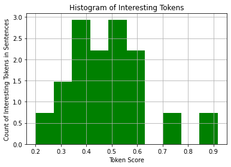

```python
sentences = list(doc.sents)
token_scores = [] # Create list for Question 6 tokens scores

def score_sentence_by_token(phrase, interesting_tok):
    for sentence in phrase:
        count_tokens = 0
        count_words = 0
        for token in sentence:
            if token in interesting_tok:
                count_tokens += 1
            if not(token.is_space or token.is_punct):
                count_words += 1

            # Makes list here for tokens for Question # 6
        if (count_words != 0):
            t_score =     count_tokens/count_words
            token_scores.append(t_score)
            #print('token', count_tokens)
            #print('word', count_words)
            #print(t_score)

        # A section to print out the score and sentence as a check
       # sent_str = str(sentence).replace('\n','').replace('  ',' ')
       # if (count_words != 0):
       #     print(round(count_tokens/count_words,2),':', sent_str)
    return

#print('The printout shows the number of interesting tokens in the sentence / number of words in the sentence: followed by the sentence.')
#print(' ')
score_sentence_by_token(sentences, interesting_tokens)
# print(token_scores)

# make token histogram
import matplotlib.pyplot as plt

# the histogram of the token data
n, bins, patches = plt.hist(token_scores, 10, density=True, facecolor='g')

plt.xlabel('Token Score')
plt.ylabel('Count of Interesting Tokens in Sentences')
plt.title('Histogram of Interesting Tokens')
plt.grid(True)
plt.show()
```

1. Make a list containing the scores (using lemmas) of every sentence in the article, and plot a histogram with appropriate titles and axis labels of the scores. From your histogram, what seems to be the most common range of scores (put the answer in a comment after your code)? ## Question 6

```
The printout shows the number of interesting lemmas in the sentence / number of words in the sentence: followed by the sentence.
```

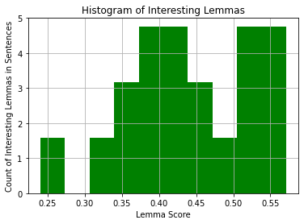

```python
lemma_scores = []  # Create list for Question 6 lemmas scores

def score_sentence_by_lemma(phrase, interesting_lem):
    for sentence in phrase:
        count_lemmas = 0
        count_words = 0
        for token in sentence:
            if token.lemma_ in interesting_lem:
                count_lemmas += 1
            if not(token.is_space or token.is_punct):
                count_words += 1

        # Makes list here for tokens for Question # 6
        if (count_words != 0):
            lemma_scores.append(count_lemmas/count_words)

        # A section to print out the score and sentence as a check
        sent_str = str(sentence).replace('\n','').replace('  ',' ')
       # if (count_words != 0):
       #     print(round(count_lemmas/count_words,2),':', sent_str)
    return

print('The printout shows the number of interesting lemmas in the sentence / number of words in the sentence: followed by the sentence.')
print(' ')
score_sentence_by_lemma(sentences, interesting_lemmas)
# print(lemma_scores)

# the histogram of the lemma data
n, bins, patches = plt.hist(lemma_scores, 10, density=True, facecolor='g')

plt.xlabel('Lemma Score')
plt.ylabel('Count of Interesting Lemmas in Sentences')
plt.title('Histogram of Interesting Lemmas')
plt.grid(True)
plt.show()
```

1. Using the histograms from questions 5 and 6, decide a "cutoff" score for tokens and lemmas such that fewer than half the sentences would have a score greater than the cutoff score. Record the scores in this Markdown cell

## Question 7

- Cutoff Score (tokens): 0.5
- Cutoff Score (lemmas): 0.5

Feel free to change these scores as you generate your summaries. Ideally, we're shooting for at least 6 sentences for our summary, but don't want more than 10 (these numbers are rough estimates; they depend on the length of your article).

1. Create a summary of the article by going through every sentence in the article and adding it to an (initially) empty list if its score (based on tokens) is greater than the cutoff score you identified in question 8. If your loop variable is named `sent`, you may find it easier to add `sent.text.strip()` to your list of sentences. Print the summary (I would cleanly generate the summary text by `join`ing the strings in your list together with a space (`' '.join(sentence_list)`). ## Question 8

```python
high_score_token = []
token_scores2 = []

for sentence in sentences:
    count_tokens = 0
    count_words = 0
    for token in sentence:
        if token in interesting_tokens:
            count_tokens += 1
        if not(token.is_space or token.is_punct):
            count_words += 1

    if (count_words != 0):
            token_scores2.append(count_tokens/count_words)
    #
    if count_words != 0 :
        if count_tokens/count_words >=0.5:
            high_score_token.append (sentence.text.strip())

print(" ".join(high_score_token))
```

```
Video Ram Transplant Doubles RTX 3070 Memory To 16 GB

            March 20, 2021 by Mike Szczys

                20 Comments





        Making unobtainium graphics cards even more unobtainable, [VIK-on] has swapped out the RAM chips on an Nvidia RTX 3070. When he first published the video showing the process of desoldering the 3070’s eight Hynix 1 GB memory chips and replacing them with eight Samsung 2 GB chips he hit the sa…




        Posted in computer hacksTagged bga, gpu, NVIDIA, ram upgrade, RTX 3070
```

1. Print the polarity score of your summary you generated with the token scores (with an appropriate label). Additionally, print the number of sentences in the summarized article. ## Question 9

```python
doc2 = nlp("".join(high_score_token))
doc2._.blob.polarity
print("Article's polarity score for senteneces with a high token score: ", doc2._.blob.polarity)
```

```
Article's polarity score for senteneces with a high token score:  0.27954545454545454
```

1. Create a summary of the article by going through every sentence in the article and adding it to an (initially) empty list if its score (based on lemmas) is greater than the cutoff score you identified in question 8. If your loop variable is named `sent`, you may find it easier to add `sent.text.strip()` to your list of sentences. Print the summary (I would cleanly generate the summary text by `join`ing the strings in your list together with a space (`' '.join(sentence_list)`). ## Question 10

```python
high_score_lemma = []

for sentence in sentences:
    count_lemmas = 0
    count_words = 0
    for token in sentence:
        if token.lemma_ in interesting_lemmas:
            count_lemmas += 1
        if not(token.is_space or token.is_punct):
            count_words += 1

    #
    if count_words != 0 :
        if count_lemmas/count_words >=0.5:
            high_score_lemma.append (sentence.text.strip())

print(" ".join(high_score_lemma))
```

```
Helpful hints from his viewers led him to use an EVGA configuration GUI to lock the operating frequency which fixed the problem. Further troubleshooting (YouTube comment in Russian and machine translation of it) showed that the “max performance mode” setting in the Nvidia tool is also a solution to …




        Posted in computer hacksTagged bga, gpu, NVIDIA, ram upgrade, RTX 3070
```

1. Print the polarity score of your summary you generated with the lemma scores (with an appropriate label). Additionally, print the number of sentences in the summarized article. ## Question 11

```python
doc3 = nlp("".join(high_score_lemma))
doc3._.blob.polarity
print("Article's polarity score for senteneces with a high lemma score: ", doc3._.blob.polarity)
```

```
Article's polarity score for senteneces with a high lemma score:  0.29727272727272724
```

1. Compare your polarity scores of your summaries to the polarity scores of the initial article. Is there a difference? Why do you think that may or may not be?. Answer in this Markdown cell.  
   ## Question 12 When selecting for higher frequency tokens and lemmas, the polarity scores went up from 0.15 for the whole article to 0.29 for the high frequency token/lemma sentences. It tells me that the lower frequency tokens and lemmas sentences were more negative, and the more positively oriented sentences were retained in the filtering.
1. Based on your reading of the original article, which summary do you think is better (if there's a difference). Why do you think this might be?

## Question 13

I would say that the high frequency token summary is a pretty good summary of the article. Showing the more positive elements left off the bits that didn't work and focused on the bits that did work. The elements that make the article a story are lost, though, so I'd definitely call it a summary. The high frequency lemma summary is enven further summarized, and in that case, it may have gone too far. It's hard to understand what the article is really tryign to say with its summary. Overall, I find it to be a good lesson in tweaking this kind of analysis, and how tricky and subjective it can me.